# Qualifying standards for World Maters Championships 2019

Marianne, Friedrich, David, Les

01 October 2018

# 1 Trend in participation in IWF world championships across years

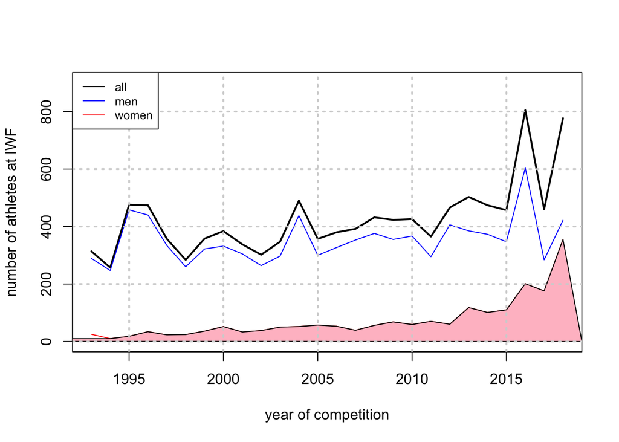

The increase in women participations has been seen in US National competitions for a while, so that the number of women surpassed those of the number of men in recent years. Among the younger age groups women outnumbered men at the IWF 2018 in Barcelona.

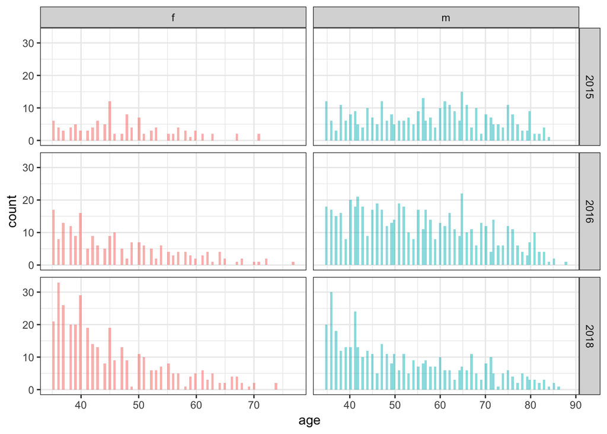

Trend in number of participants

# 2 Age and Bodyweight distribution

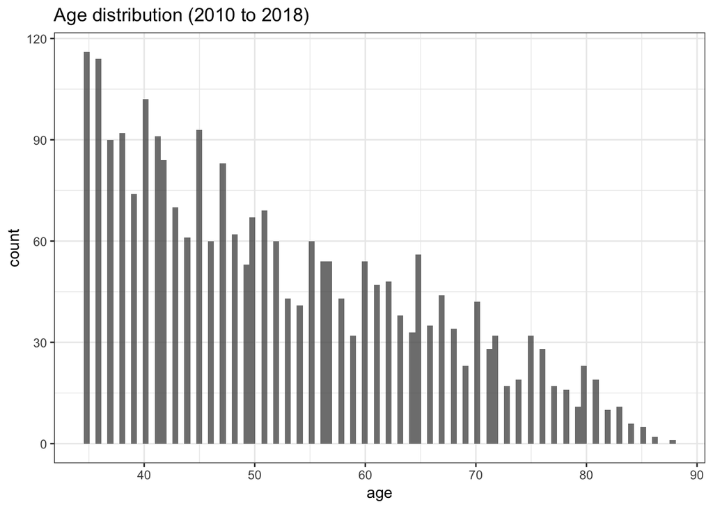

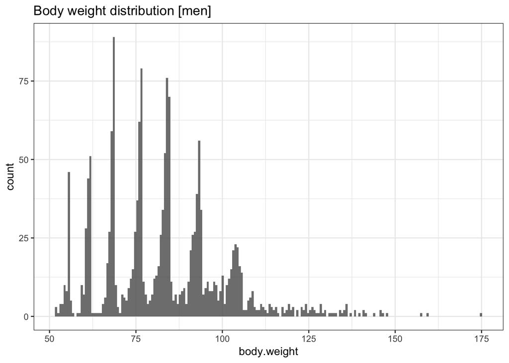

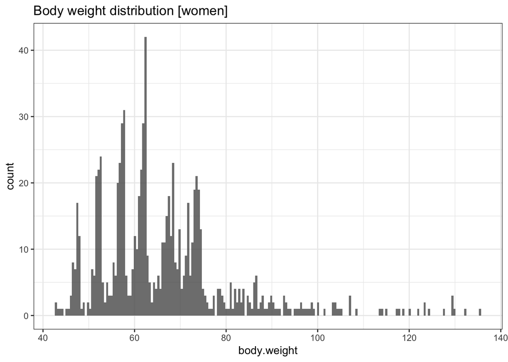

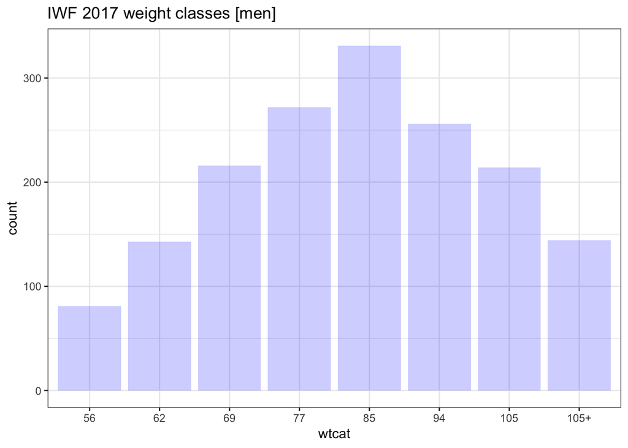

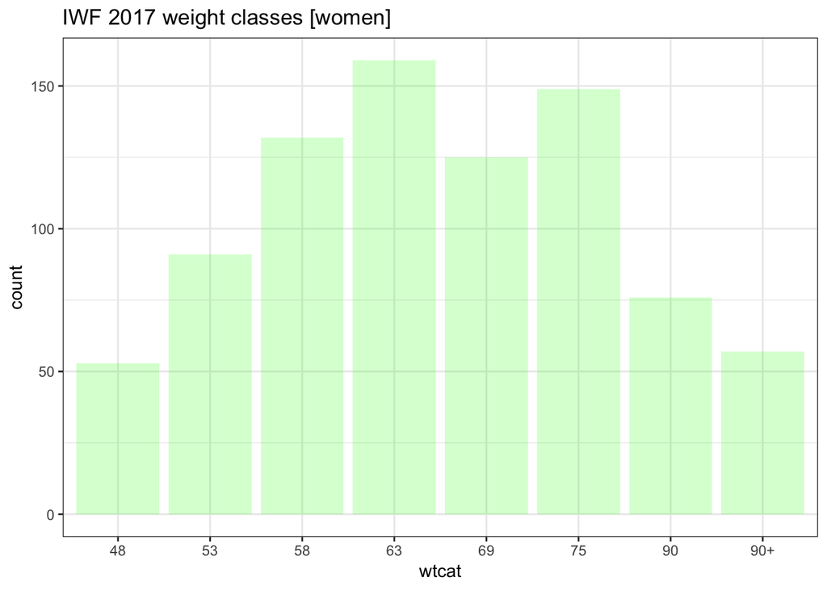

Due the body weight and age distributions it is reasonable to calculate qualifying totals [in kg] based on SMF cutoff values calculated for the top body weight in each weight class and the youngest age in each age class or youngest plus 2 year. A decision needs to be made for the heaviest weight classes. In this document the reference weight was 125 kg for men and 105kg for women.

# 3 SMF distributions for 2015 (Finland), 2016 (Germany), and 2018 (Spain)

## 3.1 SMF density plots

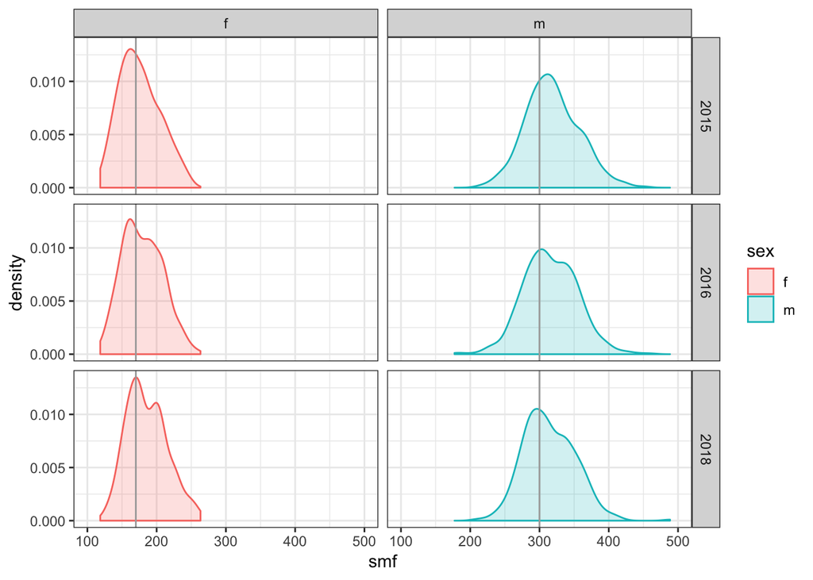

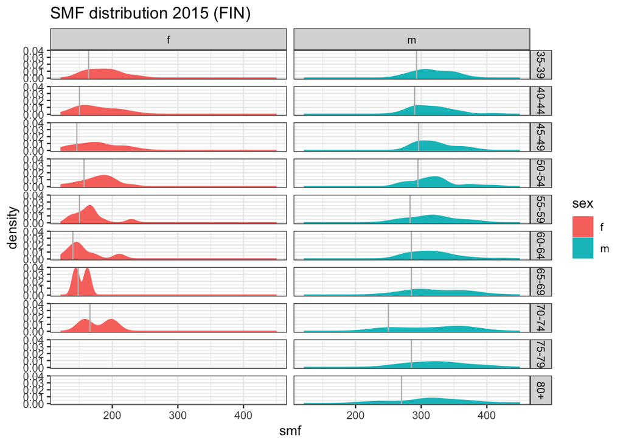

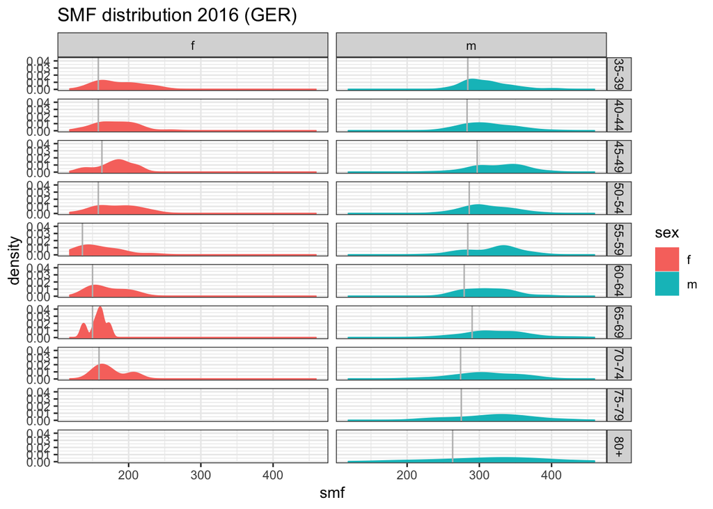

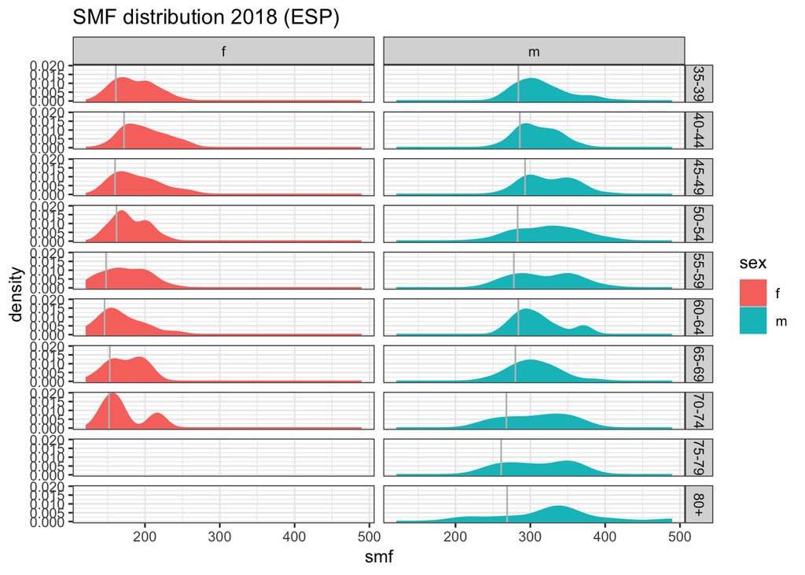

## 3.2 Tables of participants while categorizing bodyweights into the new IWF weight categories

This indicates that the most pressure is in the younger age groups in the middle weight categories.

For ease of viewing all numbers larger than 10 are in red.

### 3.2.1 IWF 2015 in Rovaniemi, Finland

| W35 | W40 | W45 | W50 | W55 | W60 | W65 | W70 | W75 | W80 | weightcat |
| --- | --- | --- | --- | --- | --- | --- | --- | --- | --- | --- |
| 1 | 0 | 0 | 0 | 0 | 0 | 0 | 0 | 0 | 0 | 45 |
| 1 | 0 | 2 | 1 | 1 | 0 | 0 | 0 | 0 | 0 | 49 |
| 4 | 1 | 2 | 3 | 2 | 3 | 0 | 1 | 1 | 0 | 55 |
| 4 | 3 | 1 | 2 | 3 | 0 | 0 | 1 | 1 | 0 | 59 |
| 3 | 4 | 5 | 3 | 3 | 2 | 1 | 0 | 0 | 0 | 64 |
| 5 | 2 | 7 | 3 | 1 | 0 | 0 | 0 | 0 | 0 | 71 |
| 2 | 7 | 4 | 2 | 0 | 1 | 0 | 0 | 0 | 0 | 76 |
| 0 | 1 | 2 | 0 | 0 | 1 | 1 | 0 | 0 | 0 | 81 |
| 1 | 1 | 1 | 0 | 1 | 0 | 0 | 0 | 0 | 0 | 87 |
| 1 | 2 | 4 | 2 | 1 | 0 | 0 | 0 | 0 | 0 | 87+ |

| M35 | M40 | M45 | M50 | M55 | M60 | M65 | M70 | M75 | M80 | weightcat |
| --- | --- | --- | --- | --- | --- | --- | --- | --- | --- | --- |
| 0 | 0 | 0 | 0 | 1 | 2 | 0 | 1 | 1 | 0 | 55 |
| 0 | 3 | 2 | 3 | 4 | 1 | 2 | 4 | 4 | 2 | 61 |
| 4 | 1 | 3 | 3 | 3 | 6 | 3 | 1 | 1 | 1 | 67 |
| 1 | 4 | 7 | 3 | 3 | 7 | 8 | 4 | 4 | 4 | 73 |
| 7 | 4 | 7 | 7 | 10 | 12 | 10 | 6 | 6 | 3 | 81 |
| 9 | 7 | 5 | 4 | 6 | 6 | 8 | 7 | 7 | 4 | 89 |
| 8 | 6 | 3 | 3 | 5 | 5 | 5 | 4 | 4 | 2 | 96 |
| 1 | 0 | 7 | 1 | 3 | 3 | 3 | 1 | 1 | 1 | 102 |
| 3 | 7 | 2 | 4 | 2 | 4 | 2 | 0 | 0 | 1 | 109 |
| 5 | 4 | 2 | 1 | 2 | 2 | 1 | 1 | 1 | 0 | 109+ |

### 3.2.2 IWF 2016 in Heinsheim, Germany

| W35 | W40 | W45 | W50 | W55 | W60 | W65 | W70 | W75 | W80 | weightcat |
| --- | --- | --- | --- | --- | --- | --- | --- | --- | --- | --- |
| 1 | 0 | 0 | 0 | 0 | 0 | 0 | 0 | 0 | 0 | 45 |
| 6 | 3 | 1 | 1 | 1 | 1 | 0 | 0 | 0 | 0 | 49 |
| 5 | 7 | 2 | 3 | 3 | 4 | 1 | 2 | 2 | 0 | 55 |
| 11 | 7 | 6 | 6 | 2 | 2 | 1 | 1 | 1 | 0 | 59 |
| 11 | 7 | 7 | 3 | 3 | 2 | 1 | 1 | 1 | 0 | 64 |
| 11 | 6 | 3 | 7 | 2 | 2 | 1 | 0 | 0 | 0 | 71 |
| 10 | 5 | 8 | 3 | 2 | 2 | 0 | 0 | 0 | 0 | 76 |
| 1 | 1 | 1 | 0 | 2 | 1 | 1 | 0 | 0 | 0 | 81 |
| 1 | 1 | 0 | 0 | 2 | 0 | 0 | 0 | 0 | 0 | 87 |
| 2 | 4 | 5 | 3 | 1 | 0 | 0 | 0 | 0 | 0 | 87+ |

| M35 | M40 | M45 | M50 | M55 | M60 | M65 | M70 | M75 | M80 | weightcat |
| --- | --- | --- | --- | --- | --- | --- | --- | --- | --- | --- |
| 0 | 1 | 2 | 0 | 1 | 2 | 1 | 0 | 0 | 0 | 55 |
| 4 | 5 | 1 | 2 | 6 | 2 | 6 | 1 | 1 | 3 | 61 |
| 4 | 3 | 3 | 3 | 6 | 8 | 6 | 4 | 4 | 4 | 67 |
| 5 | 7 | 7 | 11 | 8 | 5 | 12 | 9 | 9 | 5 | 73 |
| 9 | 16 | 12 | 11 | 11 | 10 | 10 | 7 | 7 | 8 | 81 |
| 22 | 23 | 19 | 13 | 10 | 13 | 11 | 8 | 8 | 2 | 89 |
| 15 | 15 | 17 | 9 | 7 | 10 | 9 | 7 | 7 | 6 | 96 |
| 1 | 2 | 5 | 5 | 8 | 3 | 3 | 2 | 2 | 0 | 102 |
| 8 | 4 | 10 | 8 | 5 | 5 | 2 | 3 | 3 | 1 | 109 |
| 6 | 10 | 2 | 7 | 5 | 3 | 2 | 1 | 1 | 0 | 109+ |

### 3.2.3 IWF 2018 in Barcelona, Spain

| W35 | W40 | W45 | W50 | W55 | W60 | W65 | W70 | W75 | W80 | weightcat |
| --- | --- | --- | --- | --- | --- | --- | --- | --- | --- | --- |
| 0 | 1 | 0 | 0 | 0 | 1 | 0 | 0 | 0 | 0 | 45 |
| 4 | 8 | 2 | 3 | 2 | 1 | 1 | 0 | 0 | 0 | 49 |
| 8 | 8 | 7 | 5 | 2 | 3 | 3 | 1 | 1 | 0 | 55 |
| 23 | 10 | 7 | 3 | 3 | 4 | 5 | 1 | 1 | 0 | 59 |
| 25 | 19 | 7 | 12 | 4 | 4 | 2 | 0 | 0 | 0 | 64 |
| 27 | 14 | 14 | 6 | 3 | 1 | 1 | 1 | 1 | 0 | 71 |
| 15 | 14 | 6 | 5 | 4 | 4 | 1 | 1 | 1 | 0 | 76 |
| 1 | 2 | 3 | 2 | 0 | 0 | 0 | 0 | 0 | 0 | 81 |
| 6 | 3 | 3 | 3 | 3 | 1 | 0 | 0 | 0 | 0 | 87 |
| 11 | 4 | 2 | 1 | 2 | 2 | 0 | 0 | 0 | 0 | 87+ |

| M35 | M40 | M45 | M50 | M55 | M60 | M65 | M70 | M75 | M80 | weightcat |
| --- | --- | --- | --- | --- | --- | --- | --- | --- | --- | --- |
| 0 | 2 | 0 | 1 | 0 | 1 | 1 | 2 | 2 | 0 | 55 |
| 3 | 5 | 6 | 3 | 3 | 1 | 3 | 2 | 2 | 2 | 61 |
| 2 | 2 | 1 | 2 | 4 | 4 | 4 | 4 | 4 | 0 | 67 |
| 16 | 15 | 2 | 3 | 7 | 7 | 4 | 4 | 4 | 6 | 73 |
| 15 | 10 | 10 | 5 | 8 | 5 | 4 | 6 | 6 | 1 | 81 |
| 28 | 11 | 12 | 11 | 6 | 3 | 5 | 5 | 5 | 3 | 89 |
| 14 | 14 | 7 | 5 | 3 | 3 | 3 | 4 | 4 | 0 | 96 |
| 4 | 2 | 5 | 1 | 1 | 1 | 5 | 0 | 0 | 2 | 102 |
| 6 | 7 | 6 | 4 | 4 | 4 | 2 | 2 | 2 | 1 | 109 |
| 5 | 4 | 0 | 7 | 2 | 2 | 1 | 0 | 0 | 0 | 109+ |

# 4 SMF cutoffs, qualifying totals, and number of participants

*Comment: A Poisson regression model to predict the number of lifters in each age/weight category showed that of the three predictors age, weight, and SMF, only the age group plays a statistically significant role. That means there are more lifters in the younger age groups. The larger numbers of the middle body weight classes seen in the younger age groups are too few cells, so that body weight did not reach statistical significance to predict the number of lifters. Thus is would be acceptable to focus on qualifying standards by age category only.*

Multiple scenarios will be considered.

1. Current World Master qualifying totals
2. Current (adjusted) USAW Master National qualifying totals
3. Friedrich Faber calculations
4. Other calculations

## 4.1 Current World Championships qualifying SMF

Calculations use the highest weight for each group to calculate the Sinclair total and the youngest age in age class + 2 years (e.g 37 instead of 35) to calculate the SMF from the qualifying totals. The median SMF for each age class was taken to arrive at a SMF qualifying standard currently used at the worlds. This calculations is needed so that QTs can be calculated for the new weight classes corresponding to current QTs for the old weight classes.

World championships qualifying SMF [women]

|  | W35 | W40 | W45 | W50 | W55 | W60 | W65 | W70 | W75 | W80+ |
| --- | --- | --- | --- | --- | --- | --- | --- | --- | --- | --- |
| 48 | 139 | 144 | 137 | 136 | 132 | 132 | 132 | 136 | 154 | 183 |
| 53 | 142 | 142 | 136 | 135 | 132 | 127 | 127 | 132 | 149 | 177 |
| 58 | 141 | 141 | 136 | 132 | 128 | 130 | 126 | 129 | 146 | 173 |
| 63 | 140 | 141 | 134 | 129 | 127 | 129 | 124 | 130 | 147 | 174 |
| 69 | 136 | 137 | 135 | 130 | 129 | 126 | 124 | 130 | 147 | 174 |
| 75 | 137 | 135 | 132 | 130 | 127 | 126 | 123 | 129 | 146 | 173 |
| 90 | 132 | 131 | 129 | 127 | 125 | 120 | 119 | 126 | 142 | 168 |
| 90+ | 135 | 134 | 131 | 129 | 127 | 121 | 119 | 125 | 142 | 168 |

World championships qualifying SMF [men]

|  | M35 | M40 | M45 | M50 | M55 | M60 | M65 | M70 | M75 | M80+ |
| --- | --- | --- | --- | --- | --- | --- | --- | --- | --- | --- |
| 105 | 277 | 278 | 278 | 275 | 267 | 264 | 254 | 228 | 235 | 210 |
| 105+ | 275 | 276 | 280 | 275 | 264 | 265 | 253 | 229 | 237 | 210 |
| 56 | 254 | 255 | 258 | 255 | 244 | 243 | 234 | 214 | 217 | 211 |
| 62 | 263 | 262 | 266 | 259 | 251 | 252 | 242 | 218 | 226 | 196 |
| 69 | 266 | 267 | 272 | 267 | 258 | 256 | 248 | 223 | 231 | 200 |
| 77 | 270 | 272 | 278 | 271 | 263 | 259 | 249 | 226 | 230 | 203 |
| 85 | 274 | 276 | 279 | 273 | 266 | 264 | 251 | 226 | 239 | 208 |
| 94 | 276 | 277 | 280 | 276 | 267 | 267 | 255 | 227 | 233 | 205 |

## 4.2 Comparisons of scenarios for SMF cutpoints

SMF cutpoints [men]

| agecat | M35 | M40 | M45 | M50 | M55 | M60 | M65 | M70 | M75 | M80+ |
| --- | --- | --- | --- | --- | --- | --- | --- | --- | --- | --- |
| world | 272 | 274 | 278 | 272 | 264 | 262 | 250 | 226 | 232 | 206 |
| LS | 280 | 280 | 270 | 270 | 260 | 250 | 240 | 230 | 230 | 230 |
| FF | 290 | 290 | 285 | 280 | 275 | 270 | 265 | 265 | 260 | 260 |
| MH | 300 | 300 | 285 | 275 | 265 | 260 | 255 | 250 | 245 | 240 |

SMF cutpoints [women]

| agecat | W35 | W40 | W45 | W50 | W55 | W60 | W65 | W70 | W75 | W80+ |
| --- | --- | --- | --- | --- | --- | --- | --- | --- | --- | --- |
| world | 138 | 139 | 134 | 130 | 128 | 126 | 124 | 130 | 130 | 130 |
| LS | 170 | 170 | 160 | 155 | 140 | 140 | 140 | 140 | 140 | 140 |
| FF | 175 | 175 | 170 | 160 | 155 | 150 | 150 | 150 | 150 | 150 |
| MH | 180 | 180 | 168 | 155 | 149 | 145 | 140 | 135 | 135 | 135 |

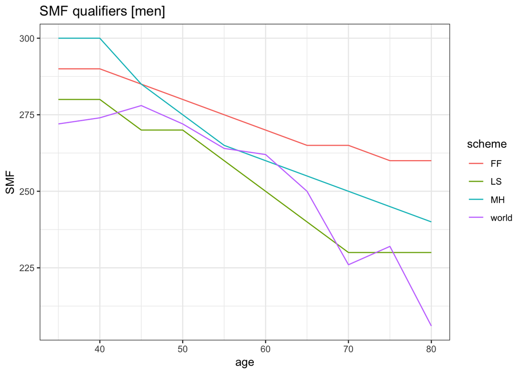

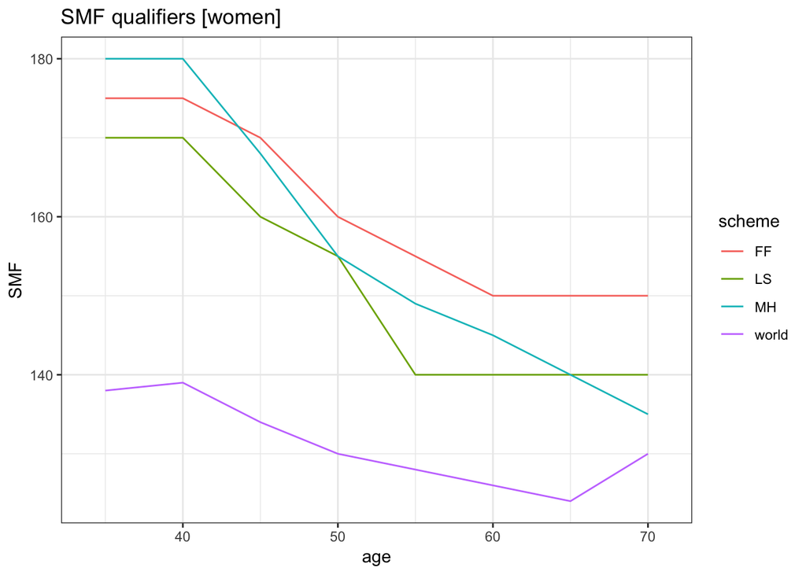

# 5 Number of qualifying athletes

In the follwing the number of qualifying athletes are calculated according to different schemes of qualifying totals based on SMF cutpoints. Howver the number appears lower, since 5 to 8% of the participants did not total.

When determining targets for registration limits, the following points need to be considered.

1. *Registration limit:* About 8 to 16% of athletes who register are not able to participate. Thus a target of 700 participants at the world championships could mean a target of 756 to 812 participants for registrations. This could also be differentiated for gender. There tend to be fewer no-shows for women than for men.
2. *SMF cutpoints:* The proportion of athletes who do not total are 5 to 8%. These are not included in the numbers below, even though they may qualify with the new qualifying standards. Thus when deciding on a sheme that should result in 700 athletes, for example, it owuld be advisable to choose a target of 644 to 665 athletes

## 5.1 Number of Lifters satisfying the qualifying standards

### 5.1.1 Example: SMF qualifying standards by FF

Qualifying totals [men]

|  | M35 | M40 | M45 | M50 | M55 | M60 | M65 | M70 | M75 | M80+ |
| --- | --- | --- | --- | --- | --- | --- | --- | --- | --- | --- |
| 55 | 170 | 161 | 149 | 137 | 123 | 111 | 98 | 87 | 74 | 62 |
| 61 | 184 | 173 | 160 | 148 | 133 | 120 | 106 | 94 | 80 | 67 |
| 67 | 195 | 184 | 171 | 157 | 141 | 127 | 113 | 100 | 85 | 71 |
| 73 | 206 | 194 | 180 | 166 | 149 | 134 | 119 | 106 | 90 | 75 |
| 81 | 218 | 205 | 190 | 175 | 157 | 142 | 125 | 112 | 95 | 79 |
| 89 | 228 | 215 | 199 | 183 | 165 | 148 | 131 | 117 | 99 | 83 |
| 96 | 235 | 222 | 205 | 189 | 170 | 153 | 135 | 120 | 102 | 85 |
| 102 | 240 | 227 | 210 | 193 | 174 | 156 | 139 | 123 | 105 | 87 |
| 109 | 246 | 232 | 215 | 198 | 178 | 160 | 142 | 126 | 107 | 89 |
| 109+ | 252 | 238 | 220 | 203 | 183 | 164 | 145 | 129 | 110 | 92 |

Qualifying totals [women]

|  | W35 | W40 | W45 | W50 | W55 | W60 | W65 | W70 | W75 | W80+ |
| --- | --- | --- | --- | --- | --- | --- | --- | --- | --- | --- |
| 45 | 96 | 90 | 83 | 73 | 65 | 57 | 52 | 46 | 40 | 33 |
| 49 | 102 | 97 | 88 | 78 | 69 | 61 | 55 | 49 | 43 | 36 |
| 55 | 112 | 105 | 96 | 85 | 75 | 67 | 60 | 54 | 46 | 39 |
| 59 | 117 | 110 | 101 | 89 | 79 | 70 | 63 | 56 | 49 | 41 |
| 64 | 123 | 116 | 106 | 94 | 83 | 74 | 66 | 59 | 51 | 43 |
| 71 | 130 | 123 | 113 | 99 | 88 | 78 | 70 | 63 | 54 | 45 |
| 76 | 135 | 127 | 117 | 103 | 91 | 81 | 73 | 65 | 56 | 47 |
| 81 | 139 | 131 | 120 | 106 | 94 | 83 | 75 | 67 | 58 | 48 |
| 87 | 143 | 135 | 124 | 109 | 97 | 86 | 77 | 69 | 60 | 50 |
| 87+ | 150 | 141 | 130 | 114 | 101 | 90 | 81 | 72 | 62 | 52 |

These are the number of lifters who reached or exceeded the qualifying totals. It does not take into account lifters who were within the 10/15 kg rule.

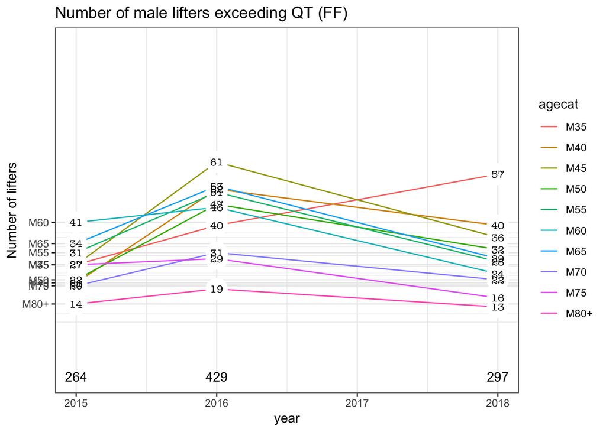

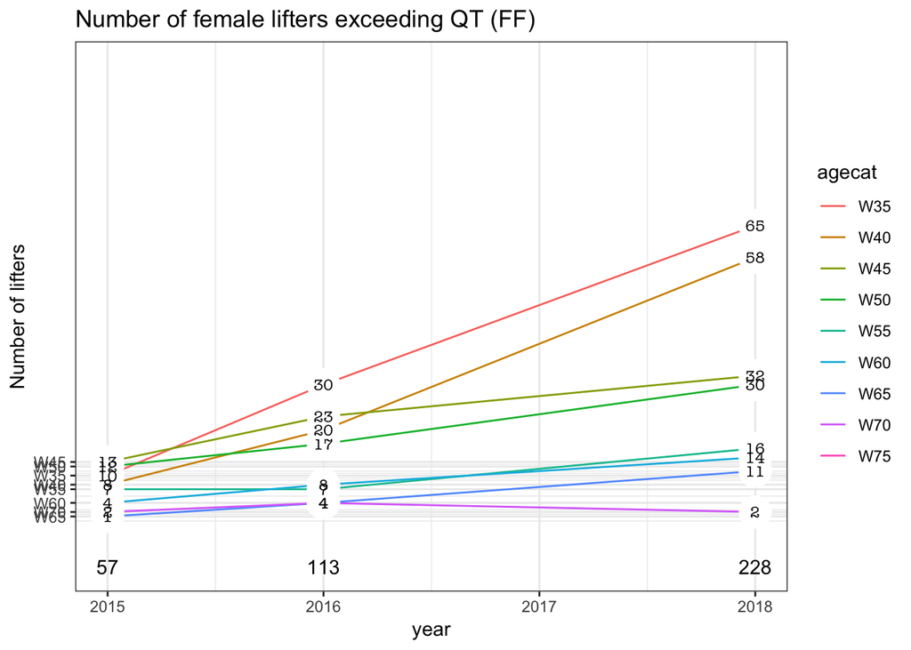

### 5.1.2 Example: SMF qualifying standards by MH

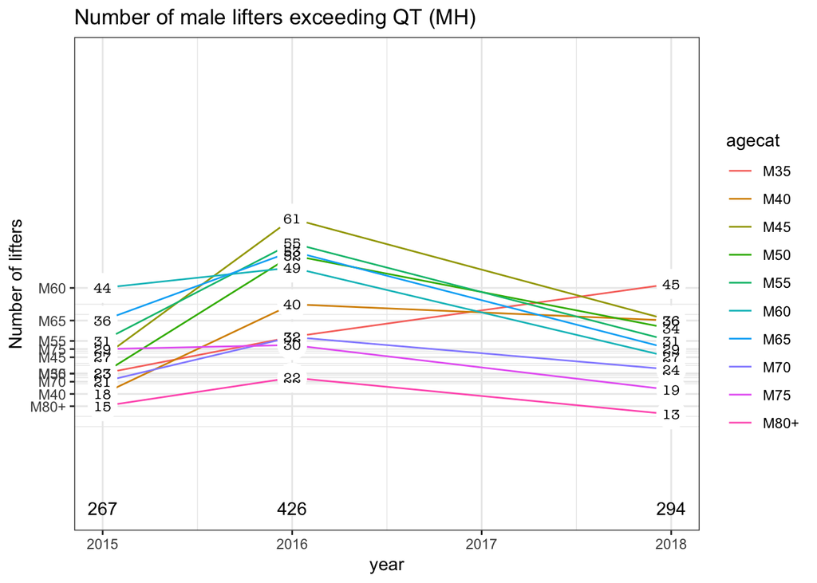

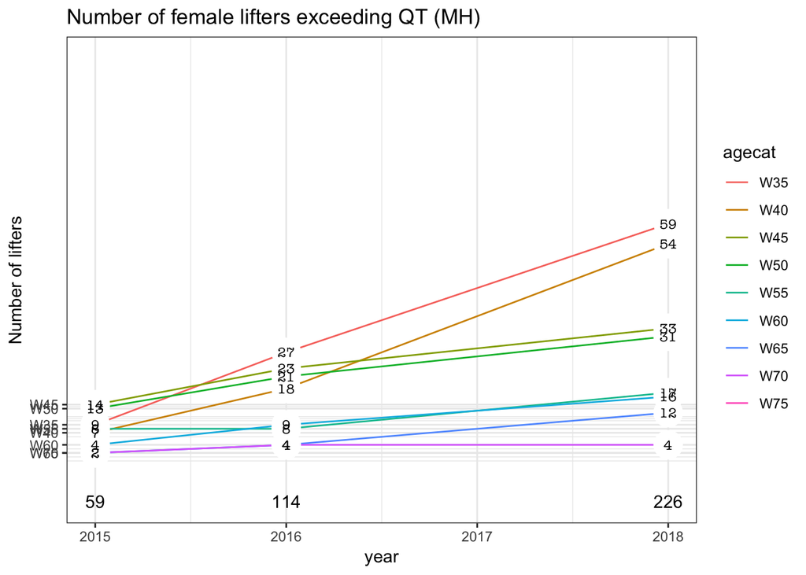

## 5.2 Number of qualifying athletes by age an weight class based on IWF 2018 (Spain)

This is based on the actual performances of the athletes at the world masters championship. Thus it does not count athletes who had a total of zero. Also note that between 10 and 30% of the lifters in age groups 35-44, 45-59, and 60+ may have had a total below the qualifying total. It is possible that the “0” number of qualifying participant for certain age/weight combinations did not have participants to begin with.

Number of men qualifying

| ageclass | wtcat | smf0 | world.tot | world.num | smf1 | LS.tot | LS.num | smf2 | FF.tot | FF.num | smf3 | MH.tot | MH.num |
| --- | --- | --- | --- | --- | --- | --- | --- | --- | --- | --- | --- | --- | --- |
| M35 | 55 | 272 | 160 | 0 | 280 | 165 | 0 | 290 | 170 | 0 | 300 | 176 | 0 |
| M35 | 61 | 272 | 172 | 1 | 280 | 177 | 1 | 290 | 184 | 1 | 300 | 190 | 0 |
| M35 | 67 | 272 | 183 | 2 | 280 | 189 | 2 | 290 | 195 | 1 | 300 | 202 | 1 |
| M35 | 73 | 272 | 193 | 13 | 280 | 199 | 11 | 290 | 206 | 9 | 300 | 213 | 7 |
| M35 | 81 | 272 | 204 | 12 | 280 | 210 | 11 | 290 | 218 | 9 | 300 | 225 | 7 |
| M35 | 89 | 272 | 214 | 21 | 280 | 220 | 17 | 290 | 228 | 15 | 300 | 235 | 12 |
| M35 | 96 | 272 | 220 | 13 | 280 | 227 | 12 | 290 | 235 | 12 | 300 | 243 | 10 |
| M35 | 102 | 272 | 225 | 3 | 280 | 232 | 2 | 290 | 240 | 2 | 300 | 249 | 1 |
| M35 | 109 | 272 | 230 | 4 | 280 | 237 | 4 | 290 | 246 | 3 | 300 | 254 | 3 |
| M35 | 109+ | 272 | 237 | 5 | 280 | 244 | 5 | 290 | 252 | 5 | 300 | 261 | 4 |
| M40 | 55 | 274 | 152 | 1 | 280 | 155 | 1 | 290 | 161 | 1 | 300 | 166 | 0 |
| M40 | 61 | 274 | 164 | 3 | 280 | 167 | 3 | 290 | 173 | 2 | 300 | 179 | 1 |
| M40 | 67 | 274 | 174 | 1 | 280 | 178 | 1 | 290 | 184 | 1 | 300 | 191 | 1 |
| M40 | 73 | 274 | 183 | 8 | 280 | 187 | 7 | 290 | 194 | 4 | 300 | 201 | 3 |
| M40 | 81 | 274 | 194 | 10 | 280 | 198 | 8 | 290 | 205 | 6 | 300 | 212 | 6 |
| M40 | 89 | 274 | 203 | 10 | 280 | 207 | 10 | 290 | 215 | 6 | 300 | 222 | 6 |
| M40 | 96 | 274 | 209 | 14 | 280 | 214 | 11 | 290 | 222 | 9 | 300 | 229 | 8 |
| M40 | 102 | 274 | 214 | 2 | 280 | 219 | 2 | 290 | 227 | 1 | 300 | 235 | 1 |
| M40 | 109 | 274 | 219 | 7 | 280 | 224 | 7 | 290 | 232 | 7 | 300 | 240 | 7 |
| M40 | 109+ | 274 | 225 | 3 | 280 | 230 | 3 | 290 | 238 | 3 | 300 | 246 | 3 |
| M45 | 55 | 278 | 145 | 0 | 270 | 141 | 0 | 285 | 149 | 0 | 285 | 149 | 0 |
| M45 | 61 | 278 | 157 | 3 | 270 | 152 | 3 | 285 | 160 | 3 | 285 | 160 | 3 |
| M45 | 67 | 278 | 167 | 1 | 270 | 162 | 1 | 285 | 171 | 1 | 285 | 171 | 1 |
| M45 | 73 | 278 | 175 | 0 | 270 | 170 | 1 | 285 | 180 | 0 | 285 | 180 | 0 |
| M45 | 81 | 278 | 186 | 9 | 270 | 180 | 9 | 285 | 190 | 7 | 285 | 190 | 7 |
| M45 | 89 | 278 | 194 | 10 | 270 | 188 | 10 | 285 | 199 | 10 | 285 | 199 | 10 |
| M45 | 96 | 278 | 200 | 5 | 270 | 194 | 5 | 285 | 205 | 5 | 285 | 205 | 5 |
| M45 | 102 | 278 | 205 | 4 | 270 | 199 | 4 | 285 | 210 | 4 | 285 | 210 | 4 |
| M45 | 109 | 278 | 209 | 6 | 270 | 203 | 6 | 285 | 215 | 6 | 285 | 215 | 6 |
| M45 | 109+ | 278 | 215 | 0 | 270 | 209 | 0 | 285 | 220 | 0 | 285 | 220 | 0 |

[output cut: 70 more lines]

Number of women qualifying

| ageclass | wtcat | smf0 | world.tot | world.num | smf1 | LS.tot | LS.num | smf2 | FF.tot | FF.num | smf3 | MH.tot | MH.num |
| --- | --- | --- | --- | --- | --- | --- | --- | --- | --- | --- | --- | --- | --- |
| W35 | 45 | 138 | 75 | 0 | 170 | 93 | 0 | 175 | 96 | 0 | 180 | 98 | 0 |
| W35 | 49 | 138 | 81 | 3 | 170 | 99 | 2 | 175 | 102 | 2 | 180 | 105 | 2 |
| W35 | 55 | 138 | 88 | 7 | 170 | 108 | 6 | 175 | 112 | 4 | 180 | 115 | 4 |
| W35 | 59 | 138 | 92 | 21 | 170 | 114 | 15 | 175 | 117 | 14 | 180 | 120 | 14 |
| W35 | 64 | 138 | 97 | 22 | 170 | 119 | 16 | 175 | 123 | 15 | 180 | 126 | 13 |
| W35 | 71 | 138 | 103 | 25 | 170 | 127 | 16 | 175 | 130 | 15 | 180 | 134 | 13 |
| W35 | 76 | 138 | 106 | 14 | 170 | 131 | 8 | 175 | 135 | 7 | 180 | 139 | 5 |
| W35 | 81 | 138 | 110 | 1 | 170 | 135 | 0 | 175 | 139 | 0 | 180 | 143 | 0 |
| W35 | 87 | 138 | 113 | 6 | 170 | 139 | 3 | 175 | 143 | 3 | 180 | 147 | 3 |
| W35 | 87+ | 138 | 118 | 9 | 170 | 146 | 5 | 175 | 150 | 5 | 180 | 154 | 5 |
| W40 | 45 | 139 | 72 | 1 | 170 | 88 | 1 | 175 | 90 | 1 | 180 | 93 | 1 |
| W40 | 49 | 139 | 77 | 8 | 170 | 94 | 8 | 175 | 97 | 6 | 180 | 99 | 6 |
| W40 | 55 | 139 | 84 | 8 | 170 | 102 | 8 | 175 | 105 | 7 | 180 | 108 | 5 |
| W40 | 59 | 139 | 88 | 10 | 170 | 107 | 9 | 175 | 110 | 9 | 180 | 113 | 9 |
| W40 | 64 | 139 | 92 | 17 | 170 | 113 | 13 | 175 | 116 | 13 | 180 | 119 | 13 |
| W40 | 71 | 139 | 98 | 13 | 170 | 119 | 11 | 175 | 123 | 10 | 180 | 126 | 9 |
| W40 | 76 | 139 | 101 | 13 | 170 | 124 | 9 | 175 | 127 | 6 | 180 | 131 | 6 |
| W40 | 81 | 139 | 104 | 2 | 170 | 127 | 2 | 175 | 131 | 2 | 180 | 135 | 2 |
| W40 | 87 | 139 | 107 | 3 | 170 | 131 | 2 | 175 | 135 | 2 | 180 | 139 | 2 |
| W40 | 87+ | 139 | 112 | 4 | 170 | 137 | 3 | 175 | 141 | 2 | 180 | 145 | 1 |
| W45 | 45 | 134 | 65 | 0 | 160 | 78 | 0 | 170 | 83 | 0 | 168 | 82 | 0 |
| W45 | 49 | 134 | 70 | 2 | 160 | 83 | 1 | 170 | 88 | 1 | 168 | 87 | 1 |
| W45 | 55 | 134 | 76 | 7 | 160 | 91 | 4 | 170 | 96 | 3 | 168 | 95 | 3 |
| W45 | 59 | 134 | 80 | 7 | 160 | 95 | 6 | 170 | 101 | 6 | 168 | 100 | 6 |
| W45 | 64 | 134 | 84 | 7 | 160 | 100 | 6 | 170 | 106 | 6 | 168 | 105 | 6 |
| W45 | 71 | 134 | 89 | 13 | 160 | 106 | 12 | 170 | 113 | 10 | 168 | 111 | 10 |
| W45 | 76 | 134 | 92 | 6 | 160 | 110 | 4 | 170 | 117 | 3 | 168 | 115 | 3 |
| W45 | 81 | 134 | 95 | 2 | 160 | 113 | 1 | 170 | 120 | 1 | 168 | 119 | 1 |
| W45 | 87 | 134 | 97 | 3 | 160 | 116 | 2 | 170 | 124 | 1 | 168 | 122 | 2 |
| W45 | 87+ | 134 | 102 | 1 | 160 | 122 | 1 | 170 | 130 | 1 | 168 | 128 | 1 |

[output cut: 70 more lines]

## 5.3 Number of qualifying athletes by age an weight class based on IWF 2016 (Germany)

Number of men qualifying

| ageclass | wtcat | smf0 | world.tot | world.num | smf1 | LS.tot | LS.num | smf2 | FF.tot | FF.num | smf3 | MH.tot | MH.num |
| --- | --- | --- | --- | --- | --- | --- | --- | --- | --- | --- | --- | --- | --- |
| M35 | 55 | 272 | 160 | 0 | 280 | 165 | 0 | 290 | 170 | 0 | 300 | 176 | 0 |
| M35 | 61 | 272 | 172 | 2 | 280 | 177 | 1 | 290 | 184 | 0 | 300 | 190 | 0 |
| M35 | 67 | 272 | 183 | 2 | 280 | 189 | 1 | 290 | 195 | 1 | 300 | 202 | 0 |
| M35 | 73 | 272 | 193 | 4 | 280 | 199 | 4 | 290 | 206 | 4 | 300 | 213 | 2 |
| M35 | 81 | 272 | 204 | 8 | 280 | 210 | 8 | 290 | 218 | 6 | 300 | 225 | 6 |
| M35 | 89 | 272 | 214 | 18 | 280 | 220 | 16 | 290 | 228 | 10 | 300 | 235 | 8 |
| M35 | 96 | 272 | 220 | 13 | 280 | 227 | 11 | 290 | 235 | 8 | 300 | 243 | 7 |
| M35 | 102 | 272 | 225 | 1 | 280 | 232 | 1 | 290 | 240 | 1 | 300 | 249 | 1 |
| M35 | 109 | 272 | 230 | 8 | 280 | 237 | 6 | 290 | 246 | 5 | 300 | 254 | 3 |
| M35 | 109+ | 272 | 237 | 5 | 280 | 244 | 5 | 290 | 252 | 5 | 300 | 261 | 5 |
| M40 | 55 | 274 | 152 | 1 | 280 | 155 | 1 | 290 | 161 | 1 | 300 | 166 | 0 |
| M40 | 61 | 274 | 164 | 2 | 280 | 167 | 2 | 290 | 173 | 1 | 300 | 179 | 1 |
| M40 | 67 | 274 | 174 | 2 | 280 | 178 | 2 | 290 | 184 | 2 | 300 | 191 | 1 |
| M40 | 73 | 274 | 183 | 3 | 280 | 187 | 3 | 290 | 194 | 3 | 300 | 201 | 2 |
| M40 | 81 | 274 | 194 | 14 | 280 | 198 | 12 | 290 | 205 | 10 | 300 | 212 | 8 |
| M40 | 89 | 274 | 203 | 18 | 280 | 207 | 17 | 290 | 215 | 14 | 300 | 222 | 10 |
| M40 | 96 | 274 | 209 | 12 | 280 | 214 | 11 | 290 | 222 | 10 | 300 | 229 | 9 |
| M40 | 102 | 274 | 214 | 2 | 280 | 219 | 2 | 290 | 227 | 1 | 300 | 235 | 0 |
| M40 | 109 | 274 | 219 | 4 | 280 | 224 | 4 | 290 | 232 | 4 | 300 | 240 | 4 |
| M40 | 109+ | 274 | 225 | 8 | 280 | 230 | 8 | 290 | 238 | 6 | 300 | 246 | 5 |
| M45 | 55 | 278 | 145 | 1 | 270 | 141 | 1 | 285 | 149 | 1 | 285 | 149 | 1 |
| M45 | 61 | 278 | 157 | 1 | 270 | 152 | 1 | 285 | 160 | 1 | 285 | 160 | 1 |
| M45 | 67 | 278 | 167 | 3 | 270 | 162 | 3 | 285 | 171 | 2 | 285 | 171 | 2 |
| M45 | 73 | 278 | 175 | 6 | 270 | 170 | 6 | 285 | 180 | 5 | 285 | 180 | 5 |
| M45 | 81 | 278 | 186 | 9 | 270 | 180 | 9 | 285 | 190 | 9 | 285 | 190 | 9 |
| M45 | 89 | 278 | 194 | 14 | 270 | 188 | 15 | 285 | 199 | 12 | 285 | 199 | 12 |
| M45 | 96 | 278 | 200 | 15 | 270 | 194 | 15 | 285 | 205 | 14 | 285 | 205 | 14 |
| M45 | 102 | 278 | 205 | 5 | 270 | 199 | 5 | 285 | 210 | 5 | 285 | 210 | 5 |
| M45 | 109 | 278 | 209 | 10 | 270 | 203 | 10 | 285 | 215 | 10 | 285 | 215 | 10 |
| M45 | 109+ | 278 | 215 | 2 | 270 | 209 | 2 | 285 | 220 | 2 | 285 | 220 | 2 |

[output cut: 70 more lines]

Number of women qualifying

| ageclass | wtcat | smf0 | world.tot | world.num | smf1 | LS.tot | LS.num | smf2 | FF.tot | FF.num | smf3 | MH.tot | MH.num |
| --- | --- | --- | --- | --- | --- | --- | --- | --- | --- | --- | --- | --- | --- |
| W35 | 45 | 138 | 75 | 1 | 170 | 93 | 1 | 175 | 96 | 1 | 180 | 98 | 0 |
| W35 | 49 | 138 | 81 | 6 | 170 | 99 | 5 | 175 | 102 | 4 | 180 | 105 | 4 |
| W35 | 55 | 138 | 88 | 5 | 170 | 108 | 2 | 175 | 112 | 2 | 180 | 115 | 2 |
| W35 | 59 | 138 | 92 | 10 | 170 | 114 | 8 | 175 | 117 | 8 | 180 | 120 | 7 |
| W35 | 64 | 138 | 97 | 11 | 170 | 119 | 8 | 175 | 123 | 6 | 180 | 126 | 5 |
| W35 | 71 | 138 | 103 | 9 | 170 | 127 | 5 | 175 | 130 | 5 | 180 | 134 | 5 |
| W35 | 76 | 138 | 106 | 9 | 170 | 131 | 4 | 175 | 135 | 4 | 180 | 139 | 4 |
| W35 | 81 | 138 | 110 | 1 | 170 | 135 | 0 | 175 | 139 | 0 | 180 | 143 | 0 |
| W35 | 87 | 138 | 113 | 1 | 170 | 139 | 0 | 175 | 143 | 0 | 180 | 147 | 0 |
| W35 | 87+ | 138 | 118 | 1 | 170 | 146 | 1 | 175 | 150 | 0 | 180 | 154 | 0 |
| W40 | 45 | 139 | 72 | 0 | 170 | 88 | 0 | 175 | 90 | 0 | 180 | 93 | 0 |
| W40 | 49 | 139 | 77 | 3 | 170 | 94 | 2 | 175 | 97 | 2 | 180 | 99 | 2 |
| W40 | 55 | 139 | 84 | 6 | 170 | 102 | 5 | 175 | 105 | 3 | 180 | 108 | 2 |
| W40 | 59 | 139 | 88 | 7 | 170 | 107 | 5 | 175 | 110 | 4 | 180 | 113 | 4 |
| W40 | 64 | 139 | 92 | 7 | 170 | 113 | 7 | 175 | 116 | 4 | 180 | 119 | 4 |
| W40 | 71 | 139 | 98 | 6 | 170 | 119 | 2 | 175 | 123 | 2 | 180 | 126 | 2 |
| W40 | 76 | 139 | 101 | 4 | 170 | 124 | 2 | 175 | 127 | 2 | 180 | 131 | 2 |
| W40 | 81 | 139 | 104 | 0 | 170 | 127 | 0 | 175 | 131 | 0 | 180 | 135 | 0 |
| W40 | 87 | 139 | 107 | 1 | 170 | 131 | 1 | 175 | 135 | 1 | 180 | 139 | 1 |
| W40 | 87+ | 139 | 112 | 4 | 170 | 137 | 2 | 175 | 141 | 2 | 180 | 145 | 1 |
| W45 | 45 | 134 | 65 | 0 | 160 | 78 | 0 | 170 | 83 | 0 | 168 | 82 | 0 |
| W45 | 49 | 134 | 70 | 1 | 160 | 83 | 1 | 170 | 88 | 1 | 168 | 87 | 1 |
| W45 | 55 | 134 | 76 | 2 | 160 | 91 | 2 | 170 | 96 | 2 | 168 | 95 | 2 |
| W45 | 59 | 134 | 80 | 6 | 160 | 95 | 4 | 170 | 101 | 3 | 168 | 100 | 3 |
| W45 | 64 | 134 | 84 | 7 | 160 | 100 | 7 | 170 | 106 | 6 | 168 | 105 | 6 |
| W45 | 71 | 134 | 89 | 3 | 160 | 106 | 3 | 170 | 113 | 3 | 168 | 111 | 3 |
| W45 | 76 | 134 | 92 | 7 | 160 | 110 | 5 | 170 | 117 | 5 | 168 | 115 | 5 |
| W45 | 81 | 134 | 95 | 1 | 160 | 113 | 0 | 170 | 120 | 0 | 168 | 119 | 0 |
| W45 | 87 | 134 | 97 | 0 | 160 | 116 | 0 | 170 | 124 | 0 | 168 | 122 | 0 |
| W45 | 87+ | 134 | 102 | 5 | 160 | 122 | 3 | 170 | 130 | 3 | 168 | 128 | 3 |

[output cut: 70 more lines]